# Curve-fitting regression problem

Just trying out the basics of scikit-learn machine learning package. Scikit-learn's API makes it easy to define, train, and test models.

Here, we do a basic example of linear regression, in the context of curve fitting. This toy example is an exact copy of tutorial available [here](https://ipython-books.github.io/featured-04/). This example will illustrate concepts such as linear models, overfitting, underfiting, regularization, and cross-validation. Let's begin.

```python
# all necessary imports
import numpy as np
import scipy.stats as st
import sklearn.linear_model as lm
import matplotlib.pyplot as plt
```

Let's define the deterministic function underlying our generative model

```python
f = lambda x: np.exp(3 * x)
```

Now, let's generate the values along the curve on [0, 2]

```python
x_tr = np.linspace(0., 2, 200)
y_tr = f(x_tr)
```

Next, we generate our data points within [0,1]. We use the function f and add some Guassian noise (why not?)

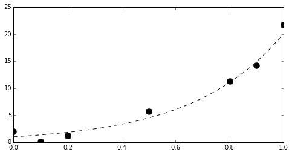

```python
x = np.array([0, .1, .2, .5, .8, .9, 1])
y = f(x) + np.random.randn(len(x))

# plot our data points on [0,1]
plt.figure(figsize=(8,4));
plt.plot(x_tr[:100], y_tr[:100], '--k');
plt.plot(x,y, 'ok', ms=10);
```

Finally, we use scikit-learn to fit a linear model to the data. The three steps are:

1. Create the model i.e. an instance of the `LinearRegression`class
2. Fit the model to our data
3. Predict the values from our trained model

```python
# create the model
lr = lm.LinearRegression()

# train the model on our training dataset
lr.fit(x[:, np.newaxis], y);

# predict the points with our trained model
y_lr = lr.predict(x_tr[:, np.newaxis])
```

It is a general convention in scikit-learn that observations are rows and features are columns. So, let's convert `x` and `x_tr` to column vectors. We have seven observations with 1 feature.

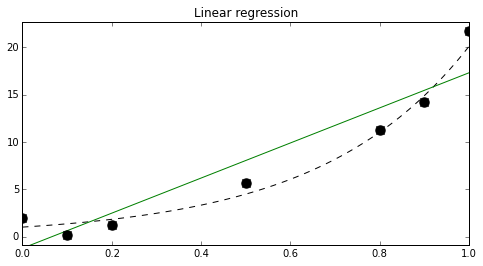

```python
# plot the result of the trained linear model
plt.figure(figsize=(8,4));
plt.plot(x_tr, y_tr, '--k');
plt.plot(x_tr, y_lr, 'g');
plt.plot(x, y, 'ok', ms=10);
plt.xlim(0, 1);
plt.ylim(y.min()-1, y.max()+1);
plt.title("Linear regression");
```

### Vandermonde matrix

The linear fit is not well adapted here as the data points are generated according to a non-linear model (an exponential curve). Therefore, we are now going to fit a nonlinear model. More precisely, we will fit a polynomial function to our data points. We can still use linear regression for that by precomputing the exponents of our data points. This is done by generating a Vandermonde matrix, using the `np.vander` function.

```
26.37 -7.83 0.00
66.67 -22.16 -125.81 125.85 -24.77 0.00
```

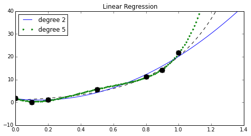

```python
lrp = lm.LinearRegression()
plt.figure(figsize=(8,4));
plt.plot(x_tr, y_tr, '--k');

for deg, s in zip([2,5], ['-', '.']):
    lrp.fit(np.vander(x, deg + 1), y);
    y_lrp = lrp.predict(np.vander(x_tr, deg + 1));
    plt.plot(x_tr, y_lrp, s, label='degree ' + str(deg));
    plt.legend(loc=2);
    plt.xlim(0,1.4);
    plt.ylim(-10, 40);

    # print the model's coefficients
    print(' '.join(['%.2f' % c for c in lrp.coef_]))

plt.plot(x, y, 'ok', ms=10);
plt.title("Linear Regression")
```

We have fitted two polynomial models of degree 2 and 5. The degree 2 polynomial appears to fit the data points less precisely than the degree 5 polynomial. However, we could say the degree 5 polynomial is **overfitting** and **less robust** simply because it would not be able to acheive a better fit outside our current dataset. Also, note the coefficients of the degree 5 polynomial is much larger which is generally a sign of overfitting.

This plot was interesting because if you look at the original tutorial, the degree 5 polynomial has much larger coefficients and the plot inverts after our largest `x-value` thereby making it less robust.

### Ridge Regression model

Now, we will use a different learning model, called the **ridge regression**. It works like linear regression, except that it prevents the polynomial's coefficients to explode. By adding a **regularization term** in the **loss function**, ridge regression imposes some structure on the underlying model.

The ridge regression model has a meta-parameter which represents the weight of the regularization term. We could try the different values with trials and errors, using the `Ridge` class. However, we will use the scikit-learn model called `RidgeCV` which includes a parameter search with cross-validation. In practise, it means that we don't have to tweak this parameter by hand: scikit-learn does it for us. Since the models of scikit-learn always follow the fit-predict API, all we have to do it replace `lm.LinearRegression` by `lm.RidgeCV`in our earlier code.

```
12.44 5.54 0.00
4.45 4.03 3.81 3.92 3.41 0.00
```

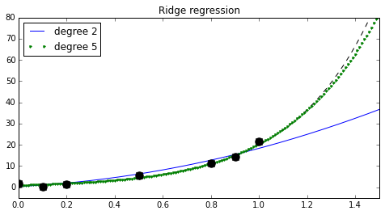

```python
ridge = lm.RidgeCV()
plt.figure(figsize=(8,4));
plt.plot(x_tr, y_tr, '--k');

for deg, s in zip([2,5], ['-', '.']):
    ridge.fit(np.vander(x, deg + 1), y);
    y_ridge = ridge.predict(np.vander(x_tr, deg + 1))
    plt.plot(x_tr, y_ridge, s, label='degree ' + str(deg));
    plt.legend(loc=2);
    plt.xlim(0, 1.5);
    plt.ylim(-5, 80);

    # print the model's coefficients
    print(' '.join(['%.2f' % c for c in ridge.coef_]))

plt.plot(x, y, 'ok', ms=10);
plt.title("Ridge regression");
```

Now, we see the degree 5 polynomial is more precise than the simpler degree 2 polynomial which now causes underfitting. Ridge regression reduces the overfitting issue here (also notice the much smaller coefficients for degree 5 polynomial).

## Additional Notes

#### Scikit-learn API

scikit-learn implements a clean and coherent API for supervised and unsupervised learning. Our data points should be a N X D matrix `X`, where `N` is the number of observations, and `D` is the number of features. In other words, each row is an observation. The first step in a machine learning task is to define what our matrix `X` is exactly.

In a supervised learning setup, we also have a target, a `N`-long vector **y** witha scalar value for each observations. This value is continuous or discrete, depending on whether we have a regression or classification problem, respectively.

In scikit-learn, models are implemented in classes that have `fit` and `predict` methods. The `fit` method accepts the data matrix **X** as input and `y` as well for supervised learning models. This method *trains* the model on the given data.

The `predict` method also takes the data points as input (as a matrix M X D). It returns the lables or transformed points, according to the trained model.